# Thermistor Data Collection

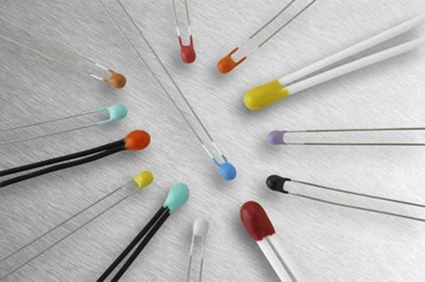

## Thermistor Basics

A thermistor (a [portmanteau](https://en.wikipedia.org/wiki/Portmanteau) of thermal and resistor) is a resistor with a higher sensitivity to thermal effects than an ordinary resistor. Thermistors are made from semiconducting materials, mostly oxides, such as

- manganese
- nickel
- cobalt

While thermistors can have practically any values, typical resistance values range from $100 \Omega$ to $500 k\Omega$. They also come in a variety of shapes and sizes. Some of the more common shapes are

- [axial](https://www.mouser.com/images/tdk/lrg/NTCDS_series_SPL.jpg)
- [radial](https://i.ebayimg.com/images/g/GDYAAOSw5~pcecUW/s-l400.jpg)
- [radial bead](https://www.digchip.com/datasheets/photos/1818/NTCLE101E3103SB0.jpg)

There are two fundamental types of thermistors determined by the thermistor's relationship between the thermistor's resistance and the thermistor's temperature. The two types are

- NTC - Negative Temperature Coefficient

NTC thermistors have an inverse temperature-resistance relationship. That is to say, as one goes up, the other goes down.

- PTC - Positive Temperature Coefficient

PTC thermistors have a direct temperature-resistance relationship. As one goes up, the other goes up as well.

## Your Thermistor

The thermistor you have in your kit is manufactured by Cantherm. It's series number is MF52. The thermistor is a pearl shaped, NTC thermistor that has a nominal resistance of $10 k\Omega \pm5\%$ with unshielded leads. Various aspects of the thermistor may be found by referring to the [datasheet](https://www.cantherm.com/wp-content/uploads/2017/05/cantherm_mf52_1.pdf). For example, the datasheet shows different lead types that are available for the thermistor. There are the tinned copper wire leads (this is what is in your kit), enamel-coated leads, high temperature fluorin-plastic insulated leads, PVC insulation, or you can even request a special type of coat for a particular use case. The datasheet also provides the dimensions of the different series of thermistors. The thermistor's dimensions may be useful if you design some case or enclosure that needs to incorporate the thermistor into the design. Reviewing the datasheet further shows a table titled Main Techno-Parameter on the last page of the datasheet. This table summarizes some of the more pertinent electrical characteristics of thermistors. It also lists the B or $\beta$ (beta) value of the thermistor. The thermistor's B value will be discussed later, so keep that in mind when the time comes. The thermistor's B value in your kit is 3470, which gives the full specification code for the thermistor to be MF52A103J3470. This code is needed by the manufacturer when purchasing more thermistors or requesting information about the thermistor. The code comes from the thermistor's various traits, and the general format may be seen on the last page of the datasheet.

## How to use it?

Before the thermistor is implemented in a measurement system, it is good practice to identify the generalized measurement system's components as it pertains to the thermistor. Shown below in Figure 1 are the different components of the generalized measurement system for the thermistor.

Figure 1: Generalized Measurement System for Thermistor

[figure not shown]

The thermistor is the sensing element, the Arduino is the signal modification portion, and the computer is the indicator. Now that the different components have been identified, the connection between the members may be discussed. The thermistor is not capable of plugging directly into the Arduino. The Arduino doesn't have a "thermistor pin". There need to be some supporting circuits to allow the Arduino to connect to the thermistor. A voltage divider circuit will enable this to happen. A voltage divider circuit utilizing a thermistor is shown below in Figure 2.

Figure 2: Thermistor Voltage Divider Circuit

[figure not shown]

The $R_t$ resistor is the thermistor. $A1$ goes to the analog pin 1 of the Arduino. The $R_b$ resistor is known as the bias resistor of the voltage divider circuit. The bias resistor gets its name from the fact that it determines the bias or offset of the voltage divider circuit. For example, consider the case where both the thermistor and bias resistor are $10k\Omega$. In this case, the expected value of the voltage at the analog read pin 1 may be determined by first calculating the current through the circuit. Find the current through the circuit is determined by calculating the equivalence resistance given by

$$ R_{eq} = R_t + R_b = 10 k\Omega + 10 k\Omega = 20 k\Omega $$

The current through both resistors $I_{tb}$ is then found by [Ohm's Law](https://en.wikipedia.org/wiki/Ohm%27s_law). The current is shown below.

$$ I_{tb} = \frac{V_s}{R_{eq}} = \frac{5V}{20 k\Omega} = 0.25 mA $$

The voltage at the analog pin $V_{ap}$ is then found by using Ohm's Law but only for the bias resistor. The analog pin voltage is shown below.

$$ V_{ap} = I_{tb} R_b = \left( 0.25 mA \right) \left( 10 k\Omega \right) = 2.5 V $$

The expression above shows that the voltage divider circuit has a bias or offset of $2.5 V$ when both the resistors are equal. A more general form of the analog pin voltage may be written by combining the three equations above. This generalized expression is shown below.

$$ V_{ap} = I_{tb} R_b = \frac{V_s}{R_{eq}} R_b = \frac{V_s}{R_t + R_b} R_b = V_s \frac{R_b}{R_t + R_b} $$

where

- $V_s$ is the supply voltage of the circuit
- $R_t$ is the thermistor resistance
- $R_b$ is the bias resistance

Quite often, you want a bias such that it is equal to half the supply voltage. With a bias that is half the supply voltage, the upper and lower parts of the full scale of the supply voltage may be equally utilized.

Now that the method of interfacing the thermistor and the Arduino is determined, the method of interfacing the Arduino and computer may be discussed. The use of an Arduino sketch may be implemented so that the computer may act as the indicator. The sketch that will be used to accomplish this may be found here. A screenshot of the code is shown below in Figure 3.

Figure 3: serial_data.ino

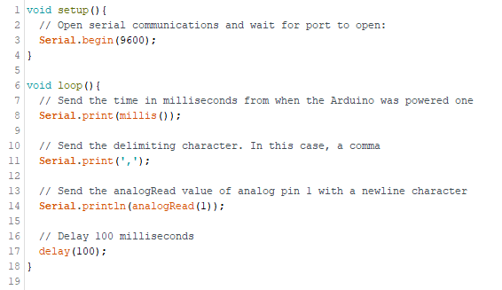

The sketch is relatively straightforward. As far as the Arduino goes, this is all that is needed. The Arduino is a capable device (especially considering its cost), but sometimes it can be slow if too much is thrown at it at once. The clock frequency of the Arduino is 16 MHz, which means it can perform sixteen million instructions a second, which may seem like a lot, but for modern computers, it is a bit slow. For example, a typical laptop nowadays has a clock frequency of anywhere from 1 to 3 GHz. That is an order of magnitude faster then the Arduino. For this reason, the sketch is kept simple.

If the sketch is run on the Arduino with the thermistor connected using the voltage divider circuit, on the Arduino IDE's serial monitor, the `millis()` function output, a comma, and then the `analogRead()` function output should be displayed. The data displayed is great, but analogRead values don't provide any information about the temperature without some help. This is where the `analogRead()` function ADC formula is utilized. The formula is shown below.

$$ V_{ap} = aR \frac{V_s}{1023} = aR \frac{5V}{1023} $$

where $aR$ is the analogRead value displayed on the serial monitor. The expression above still does not provide the temperature value that the thermistor is experiencing. The previously derived expression for the analog pin voltage $V_{ap}$ may be used with the expression above. Combining the two expressions is shown below.

$$ aR \frac{V_s}{1023} = V_s \frac{R_b}{R_t + R_b} $$

Solving for the thermistor resistance $R_t$ shows

$$ R_t = \frac{1 - \frac{aR}{1023}}{\frac{aR}{1023}} R_b $$

The expression above is useful. First, it shows that the thermistor's resistance depends on only the analogRead value and the bias resistor (not the supply voltage). Second, the relationship between a thermistor's resistance and the temperature it is experiencing behaves predictably (this is what thermistors are designed for). The thermistor's resistance-temperature relationship needs to be determined. There are two ways to determine a thermistor's resistance-temperature relationship.

- Calibration
- Manufacturer's Theoretical Expression

## Calibration

Definition:

1. **Calibration** - A process in which the output of a measurement system is compared to known values of the measurand.

There are two types of calibration: static and dynamic. The simplest to perform is a static calibration.

Definition:

1. **Static Calibration** - A particular type of calibration when the measurand changes slowly enough that time is not a factor.

When performing a calibration it is best if known values are standards. However, it often times more practical to use a second measuring system of a known accuracy. The calibration procedure is

1. Record the output of the measurement system for a particular known value.
2. Repeat step 1 for different known values. Often, the more, the better.
3. Create a calibration curve to "fit" the known values to measurement system output.

## Manufacturer's Theroetical Expression

In some cases, sensor accuracy expected from the manufacturer may be adequate. In these case, the manufacturer's theoretical expression may be used. For the thermistor in your kit, the manufacturer's theoretical expression may be found from their website [here](https://www.cantherm.com/product_post_type/mf52-2/). Following the [R-t Characteristics of Common Specs](https://www.cantherm.com/rt-characteristics/) link (the red button) on the thermistor's webpage shows the following expression.

$$ B = \ln \frac{\frac{R_{T_1}}{R_{T_2}}}{\frac{1}{T_1} - \frac{1}{T_2}} = \frac{T_1 T_2}{T_2 - T_1} \ln \frac{R_{T_1}}{R_{T_2}}$$

This expression shows how the $B$ value of the thermistor is determined. The manufacturer exposes the thermistor to a known temperature for a given thermistor and then records the resistance value. These are the $T_1$ and $R_{T_1}$ values, respectively. These values are known as the thermistor's reference state. For your thermistor, the values are $298.15 K$ and $10 k\Omega$. The manufacturer then repeats this step for another known temperature value. This is what the $T_2$ and $R_{T_2}$ values are. Once those are determined, the $B$ value may be calculated. This $B$ value represents the thermistor's resistance-temperature relationship and is reported in the thermistor's datasheet as previously discussed (your thermistor's $B$ value is $3470 K$). The usefulness of the $ B $ values comes into play when trying to determine the thermistor's temperature with the thermistor's resistance being known. Solving for $T_2$ shows

$$ T_2 = \frac{B}{\ln \left(\frac{R_2}{R_1} e^{\frac{B}{T_1}}\right)} $$

where

- $T_2$ is the temperature of the thermistor in $K$
- $B$ is the beta value of the thermistor ($3470 K$)
- $R_2$ is the resistance of the thermistor in $k\Omega$
- $R_1$ is the reference resistance ($10 k\Omega$)
- $T_1$ is the reference temperature ($298.15 K$)

This expression may be implemented in Python as a function. The expression in Python is shown below.

```python
import math

# define function that takes the resistance value of the thermistor and
# converts it to temperature in degC by using the manufacturer's theorectical
# expression.
# R2 - numeric in ohms
# B  - (optional) numeric in Kelvin that represents beta value of thermistor
# R1 - (optional) numeric in ohms that represents the thermistor calibration
#      resistance point
# T1 - (optional) numeric in Kelvin that represents the thermistor calibration
#      temperature point
# Kelvin - (optional) boolean that determines whether the returned temperature
#          value will be in Kelvin or degC
def therm_theo_exp(R2, B = 3470, R1 = 10000, T1 = 298.15, Kelvin = False):
    unitConversion = 273.15
    if Kelvin:
        unitConversion = 0
    T = B/math.log((R2/R1)*math.exp(B/T1)) - unitConversion
    return T
```

It may be seen that some arguments have an equal sign following them. In Python, these arguments are known as optional arguments. They may be used, but they do not have to be used. They are optional. If the optional argument is used, then the value given when the function is used will be used in the function; otherwise the value following the equal sign for the argument will be used. For example, if a `B` argument is given when the function is used, then that `B` value is used in the function; otherwise, the value of 3470 will be used. This feature allows for the convenient use of a function while still allowing for flexibility. For example, say that a thermistor, just like the one in your kit, is to be used, and the temperature value is to be calculated using the function `therm_theo_exp()`. Python could calculate the temperature by

```python
R = 16640.63 # Resistance in ohms
print(therm_theo_exp(R)) # temperature in degC
```

```
12.500799721719318
```

Now let's say a different thermistor is to be used, one in which the reference state is $400 K$ and $20 k\Omega$. The same `therm_theo_exp()` function may be used, but this time, the optional arguments will be specified.

```python
print(therm_theo_exp(R, T1 = 400, R1 = 20000))
```

```
135.51246554572748
```

Notice how the optional arguments are used. They don't have to be in any particular order, and not all the optional arguments must be used (the `Kelvin` argument was not used). The `Kelvin` argument makes the function output either $^\circ C$ or $K$. Using the argument is shown below.

```python
print(therm_theo_exp(R, Kelvin = True)) # temperature in K
```

```
285.6507997217193
```

Download Complete Python Script Here